# ONS Mortality Analysis Training Package

Office for National Statistics (ONS)

August 2025

# Unit: Key Concepts – Mortality Rates in R

## Overview

This document is part of the ONS mortality analysis training package.  
It supports the **Key Concepts** unit and demonstrates how to calculate a range of mortality rates using R.  
These methods align with ONS guidance and are used in official statistics and public health reporting.

## Purpose

To provide practical examples of calculating mortality rates using synthetic data.

## Rates Covered

1. Crude Mortality Rate  
Additional: Crude Mortality Rate by Sex  
2. Age-Specific Mortality Rate Additional: Age-Specific Mortality Rate by Region (England Only)  
3. Age-Standardised Mortality Rate (ASMR)  
4. Infant Mortality Rate  
5. Perinatal Mortality Rate  
6. Maternal Mortality Rate  
7. Years of Life Lost (YLL)  
8. Years of Working Life Lost (YWLL)  
9. Mean Age at Death  
Additional: Mean Age at Death by Region  
10. Crude Rate of YLL  
11. Potential Years of Life Lost (PYLL) and Standardised PYLL (SYLL)  
Additional: Registration Delays  
Additional: Registration Delays by Certification Type

Unit: Life Expectancy Methods & Modelling Expected Deaths and Excess Mortality  
Modelling Expected Deaths and Excess Mortality  
Life Expectancy Calculation Using Life Table Methods

## Learning Outcomes

- Understand key mortality concepts and terminology
- Apply standard methods to calculate mortality rates
- Interpret and present mortality statistics responsibly

## Data Requirements

The following files are provided with this training unit:

- `synthetic_death_registration_dataset.csv`  
  > Contains 153,198 synthetic death records for England and Wales, including neonatal deaths
- `synthetic_death_registration_data_dictionary.xlsx`  
  > Describes all variables in the synthetic death registration dataset
- `synthetic_birth_notifications_dataset.csv`  
  > Contains synthetic birth notification records for England and Wales
- `synthetic_birth_notifications_dictionary.csv`  
  > Describes all variables in the synthetic birth notifications dataset
- `mid_year_population_estimates.csv`  
  > Contains mid-year population estimates for:
  - England and Wales
  - England
  - Wales
  - Regions
- `european_standard_population.csv`  
  > Provides standard population weights for ASMR calculations

## Setup: Package Loading

```r
# Load Required Packages
library(readr)    # For reading CSV files
library(readxl)   # For reading Excel files
library(dplyr)    # For data manipulation
```

```r
library(ggplot2)  # Optional: for visualisation
library(tidyr)    # Optional: for reshaping data
library(lubridate)  # Handles date formats and calculations
```

# Load Data Files with Checks

### 1. Death Registration Dataset

```r
if (!file.exists("../Data/synthetic_death_registration_dataset.csv")) {
  stop("Death registration dataset not found. Please check your file path.")
}
deaths <- read_csv("../Data/synthetic_death_registration_dataset.csv")
```

### 2. Mid-Year Population Estimates

```r
if (!file.exists("../Data/mid_year_population_estimates.csv")) {
  stop("Population estimates file not found.")
}
population_estimates <- read_csv("../Data/mid_year_population_estimates.csv")
```

### 3. European Standard Population Weights

```r
if (!file.exists("../Data/european_standard_population.csv")) {
  stop("European Standard Population file not found.")
}
esp_weights <- read_csv("../Data/european_standard_population.csv")
```

### 4. Birth Notifications Dataset

```r
if (!file.exists("../Data/synthetic_birth_notifications_dataset.csv")) {
  stop("Birth notifications dataset not found. Please check your file path.")
}
births <- read_csv("../Data/synthetic_birth_notifications_dataset.csv")
```

## Optional: Load Data Dictionaries

### 5. Death Registration Data Dictionary *(Optional)*

```r
if (file.exists("../Data/synthetic_death_registration_data_dictionary.xlsx")) {
  death_dictionary <- read_excel("../Data/synthetic_death_registration_data_dictionary.xlsx")
} else {
  warning("Death registration data dictionary not found.")
}
```

### 6. Birth Notifications Data Dictionary *(Optional)*

```r
if (file.exists("../Data/synthetic_birth_notifications_dictionary.csv")) {
  birth_dictionary <- read_csv("../Data/synthetic_birth_notifications_dictionary.csv")
} else {
  warning("Birth notifications data dictionary not found.")
}
```

# Preview Data (Optional for Learners)

```
cat("Death Registration Dataset:\n")
head(deaths)
```

#### Death Registration Dataset

| ADDRDT | ADDRIT | AGEC | AGECS | AGECUNIT | Agegroup | Agegroup2 | AGEINYRS | AGEU1DST | CERTTYPE | CTRYIR | CTRYR | DEC_STAT_DOB | DOBDY | DOBMT | DOBS | DOBT | DOBYR | DOD | DODDY | DODMT | DODT | DODYR | DOR | DORT | FIC10IND | FIC10MEN01 | FIC10MEN02 | FIC10MEN03 | FIC10MEN04 | … |
| --- | --- | --- | --- | --- | --- | --- | --- | --- | --- | --- | --- | --- | --- | --- | --- | --- | --- | --- | --- | --- | --- | --- | --- | --- | --- | --- | --- | --- | --- | --- |
| 30 Main Street, Cardiff, UK | 176 Station Road, Leeds, UK | 2 | NA | 4 | <1 | <1 | 0 | NA | 9 | 2 | UK | 20241013 | 13 | 10 | NA | 13/10/2024 | 2024 | 2024-10-15 | 15 | 10 | 15/10/2024 | 2024 | 2024-10-28 | 28/10/2024 | NA | NA | NA | NA | NA | … |
| 1 Park Avenue, Leeds, UK | 152 Church Lane, Manchester, UK | 0 | NA | 4 | <1 | <1 | 0 | 3 | 6 | 2 | UK | 20240406 | 6 | 4 | NA | 06/04/2024 | 2024 | 2024-04-06 | 6 | 4 | 06/04/2024 | 2024 | 2024-04-14 | 14/04/2024 | NA | NA | NA | NA | NA | … |
| 125 Station Road, Oxford, UK | 64 Park Avenue, York, UK | 0 | NA | 4 | <1 | <1 | 0 | 2 | 6 | 1 | UK | 20240114 | 14 | 1 | NA | 14/01/2024 | 2024 | 2024-01-14 | 14 | 1 | 14/01/2024 | 2024 | 2024-01-20 | 20/01/2024 | NA | NA | NA | NA | NA | … |
| 44 Park Avenue, Manchester, UK | 172 Park Avenue, York, UK | 6 | NA | 4 | <1 | <1 | 0 | NA | 6 | 1 | UK | 20240104 | 4 | 1 | NA | 04/01/2024 | 2024 | 2024-01-10 | 10 | 1 | 10/01/2024 | 2024 | 2024-01-24 | 24/01/2024 | NA | NA | NA | NA | NA | … |
| 50 Church Lane, London, UK | 181 High Street, Norwich, UK | 3 | NA | 4 | <1 | <1 | 0 | NA | 8 | 2 | UK | 20240116 | 16 | 1 | NA | 16/01/2024 | 2024 | 2024-01-19 | 19 | 1 | 19/01/2024 | 2024 | 2024-01-26 | 26/01/2024 | NA | NA | NA | NA | NA | … |
| 198 High Street, Leeds, UK | 116 High Street, London, UK | 6 | NA | 4 | <1 | <1 | 0 | NA | 2 | 2 | UK | 20241101 | 1 | 11 | NA | 01/11/2024 | 2024 | 2024-11-07 | 7 | 11 | 07/11/2024 | 2024 | 2024-11-19 | 19/11/2024 | NA | NA | NA | NA | NA | … |

```
cat("Mid-Year Population Estimates:\n")
head(population_estimates)
```

#### Mid-Year Population Estimates

| Popn | Year | Areatype | Sex | Code | Name | Age | Agegroup2 | Agegroup |
| --- | --- | --- | --- | --- | --- | --- | --- | --- |
| 14308 | 2024 | REG | 1 | E12000001 | NORTH EAST | 4 | 01-04 | 01-04 |
| 44277 | 2024 | REG | 1 | E12000002 | NORTH WEST | 4 | 01-04 | 01-04 |
| 32255 | 2024 | REG | 1 | E12000003 | YORKSHIRE AND THE HUMBER | 4 | 01-04 | 01-04 |
| 28040 | 2024 | REG | 1 | E12000004 | EAST MIDLANDS | 4 | 01-04 | 01-04 |
| 36796 | 2024 | REG | 1 | E12000005 | WEST MIDLANDS | 4 | 01-04 | 01-04 |
| 38579 | 2024 | REG | 1 | E12000006 | EAST | 4 | 01-04 | 01-04 |

```
cat("European Standard Population Weights:\n")
head(esp_weights)
```

#### European Standard Population Weights

| agegroup | esp |
| --- | --- |
| <1 | 1000 |
| 01-04 | 4000 |
| 05-09 | 5500 |
| 10-14 | 5500 |
| 15-19 | 5500 |
| 20-24 | 6000 |

```
cat("Birth Notifications Dataset:\n")
head(births)
```

#### Birth Notifications Dataset

| MULTBTH | NHSNO | ORGCODE | PCDRB | SBIND | SEQU_NUM | SEX | SGA | SUSCONA | TERM | YEAR | AGEBM | AGEBM_GRP | BTHWGT | BTHWGT_GRP | CHORG | CONFORD | CONFNUM | DELTIME | DELTYPE | DOBM | DOB | GEST | GEST10 | GEST_GRP | MNHSNO |
| --- | --- | --- | --- | --- | --- | --- | --- | --- | --- | --- | --- | --- | --- | --- | --- | --- | --- | --- | --- | --- | --- | --- | --- | --- | --- |
| NA | 4757397410 | ORG537 | SW1A 9D | NA | 1 | 2 | 0 | N | Post term | 2024 | 37 | 35-39 | 4130 | 4000-4499 | CH7003 | 05 | 05 | 11:00:00 | 7 | 20/02/1987 | 11/02/2024 | 28 | 28 | 28-31 | 8668911250 |
| NA | 0879480294 | ORG809 | SW1A 2C | NA | 2 | 1 | 1 | Y | Term | 2024 | 36 | 35-39 | 2630 | 2500-2999 | CH8810 | 07 | 09 | 23:02:00 | 4 | 29/06/1988 | 20/06/2024 | 42 | 42 | 37+ | 9888023118 |
| NA | 0522301551 | ORG453 | SW1A 4B | NA | 3 | 1 | 0 | N | Term | 2024 | 41 | 40+ | 2752 | 2500-2999 | CH7321 | 06 | 06 | 20:26:00 | 2 | 10/08/1983 | 30/07/2024 | 32 | 32 | 32-36 | 7402423617 |
| NA | 8697512869 | ORG675 | SW1A 1A | NA | 4 | 2 | 0 | N | Post term | 2024 | 37 | 35-39 | 4154 | 4000-4499 | CH6774 | 09 | 01 | 12:11:00 | 1 | 25/11/1987 | 15/11/2024 | 25 | 25 | < 24 | 3107394963 |
| NA | 9796064168 | ORG648 | M1 8D | NA | 5 | 1 | 0 | N | Very Pre-term | 2024 | 37 | 35-39 | 1897 | 1500-1999 | CH4285 | 02 | 07 | 16:09:00 | 2 | 20/07/1987 | 10/07/2024 | 40 | 40 | 37+ | 8182099312 |
| NA | 2373364465 | ORG949 | M1 6A | NA | 6 | 1 | 0 | N | Term | 2024 | 47 | 40+ | 3911 | 3500 - 3999 | CH7536 | 05 | 02 | 07:29:00 | 1 | 21/05/1977 | 09/05/2024 | 22 | 22 | < 24 | 7077388435 |

```
cat("Death Registration Data Dictionary:\n")
head(death_dictionary)
```

#### Death Registration Data Dictionary

| Source | Name | Definition | Values | Type |
| --- | --- | --- | --- | --- |
| Deaths | ADDRDT | Deceased Usual Residence Concatenated Address | Deceased Address | Character |
| Deaths | ADDRIT | Informant Concatenated Address | Informant Address | Character |
| Deaths | AGEC | Calculated Deceased Age | 0 - 120 | Numeric |
| Deaths | AGECS | Partner Age | 16-120 | Numeric |
| Deaths | AGECUNIT | Calculated Deceased Age Unit | 1= years | Numeric |
| Deaths | AGECUNIT | Calculated Deceased Age Unit | 2= months | Numeric |

```
cat("Birth Notifications Data Dictionary:\n")
head(birth_dictionary)
```

#### Birth Notifications Data Dictionary

| Source | Variable | Description | Format | Values | Type |
| --- | --- | --- | --- | --- | --- |
| Birth notifications | AGEBM | Age of mother at birth derived from DOBM and DOB | 00-99 | In years | Numeric |
| Birth notifications | AGEBM_GRP | Grouped mothers age derived from AGBM | <20 | In years | Numeric |
| Birth notifications | AGEBM_GRP | Grouped mothers age derived from AGBM | 20-24 | In years | Numeric |
| Birth notifications | AGEBM_GRP | Grouped mothers age derived from AGBM | 25-29 | In years | Numeric |
| Birth notifications | AGEBM_GRP | Grouped mothers age derived from AGBM | 30-34 | In years | Numeric |
| Birth notifications | AGEBM_GRP | Grouped mothers age derived from AGBM | 35-39 | In years | Numeric |

# Mortality Rates

## 1. Crude Mortality Rate

```r
# Step 1: Count the total number of deaths
# Each row in the 'deaths' dataset represents one registered death
total_deaths <- nrow(deaths)

# Step 2: Sum the total population for England and Wales
# The 'population_estimates' dataset includes population broken down by age and sex
# We filter for rows where Areatype is "E&W" (England and Wales)
# Then we sum the 'Popn' column to get the total population
total_population <- population_estimates %>%
  filter(Areatype == "E&W") %>%
  summarise(total_pop = sum(Popn, na.rm = TRUE)) %>%
  pull(total_pop)

# Step 3: Calculate the Crude Mortality Rate
# Formula: (Total Deaths / Total Population) * 100,000
# This gives the number of deaths per 100,000 population
crude_mortality_rate <- (total_deaths / total_population) * 100000

# Step 4: Display the result
# We round the result to 2 decimal places for readability
cat("Crude Mortality Rate (per 100,000 population):", round(crude_mortality_rate, 2), "\n")
```

```
## Crude Mortality Rate (per 100,000 population): 247.87
```

## Additional: Crude Mortality Rate by Sex

```r
# Step 1: Count total deaths by sex
deaths_by_sex <- deaths %>%
  group_by(SEX) %>%
  summarise(total_deaths = n(), .groups = "drop")

# Step 2: Sum population by sex for England and Wales
population_by_sex <- population_estimates %>%
  filter(Areatype == "E&W") %>%
  group_by(Sex) %>%
  summarise(total_population = sum(Popn, na.rm = TRUE), .groups = "drop")

# Step 3: Join deaths and population data by sex
crude_rate_by_sex <- deaths_by_sex %>%
  left_join(population_by_sex, by = c("SEX" = "Sex")) %>%
  mutate(
    crude_rate = round((total_deaths / total_population) * 100000, 2),
    sex_label = case_when(
      SEX == 1 ~ "Male",
      SEX == 2 ~ "Female",
      TRUE ~ "Unknown"
    )
  )

# Step 4: Display results using cat()
crude_rate_by_sex %>%
  rowwise() %>%
  mutate(
    output = paste0("Crude Mortality Rate for ", sex_label, " (per 100,000 population): ", crude_rate)
  ) %>%
  pull(output) %>%
  cat(sep = "\n")
```

```
## Crude Mortality Rate for Male (per 100,000 population): 254.39
## Crude Mortality Rate for Female (per 100,000 population): 241.6
```

## 2. Age-Specific Mortality Rate

```r
# Step 1: Count total deaths by age group
# We group the 'deaths' dataset by Agegroup2 and count the number of records in each group.
# This gives us the total number of deaths per age group.
deaths_by_age <- deaths %>%
  group_by(Agegroup2) %>%
  summarise(total_deaths = n())

# Step 2: Sum population by age group for England and Wales
# We filter the population estimates to include only England & Wales (Areatype == "E&W"),
# then group by Agegroup2 and sum the population within each group.
population_by_age <- population_estimates %>%
  filter(Areatype == "E&W") %>%
  group_by(Agegroup2) %>%
  summarise(total_population = sum(Popn, na.rm = TRUE))

# Step 3: Join deaths and population data by age group
# We perform a left join to combine the deaths and population datasets by Agegroup2.
# This ensures all age groups from the deaths data are retained, even if population data is missing.
# We then calculate the Age-Specific Mortality Rate (ASMR) per 100,000 population.
age_specific_rates <- deaths_by_age %>%
  left_join(population_by_age, by = "Agegroup2") %>%
  mutate(ASMR = (total_deaths / total_population) * 100000)

# Step 4: Display results in a readable format
# We round the ASMR to two decimal places for clarity.
# Then, for each age group, we create a formatted string describing the ASMR.
# Finally, we print each line using cat(), which outputs to the console.
age_specific_rates %>%
  mutate(ASMR = round(ASMR, 2)) %>%
  rowwise() %>%
  mutate(
    output = paste0("Age-Specific Mortality Rate for ", Agegroup2, " (per 100,000): ", ASMR)
  ) %>%
  pull(output) %>%
  cat(sep = "\n")
```

```
## Age-Specific Mortality Rate for 01-04 (per 100,000): 7.33
## Age-Specific Mortality Rate for 05-09 (per 100,000): 4.48
## Age-Specific Mortality Rate for 10-14 (per 100,000): 5.09
## Age-Specific Mortality Rate for 15-19 (per 100,000): 14.77
## Age-Specific Mortality Rate for 20-24 (per 100,000): 20.81
## Age-Specific Mortality Rate for 25-29 (per 100,000): 24.45
## Age-Specific Mortality Rate for 30-34 (per 100,000): 34.35
## Age-Specific Mortality Rate for 35-39 (per 100,000): 54.1
## Age-Specific Mortality Rate for 40-44 (per 100,000): 81.85
## Age-Specific Mortality Rate for 45-49 (per 100,000): 122.35
## Age-Specific Mortality Rate for 50-54 (per 100,000): 190.61
## Age-Specific Mortality Rate for 55-59 (per 100,000): 279.06
## Age-Specific Mortality Rate for 60-64 (per 100,000): 384.15
## Age-Specific Mortality Rate for 65-69 (per 100,000): 369.02
## Age-Specific Mortality Rate for 70-74 (per 100,000): 628.09
## Age-Specific Mortality Rate for 75-79 (per 100,000): 554.65
## Age-Specific Mortality Rate for 80-84 (per 100,000): 897.84
## Age-Specific Mortality Rate for 85+ (per 100,000): 2978.36
## Age-Specific Mortality Rate for <1 (per 100,000): 116.41
```

## Additional: Age-Specific Mortality Rate by Region (England Only)

```r
# Step 1: Filter deaths to England only and count by age group and region
deaths_by_age_region <- deaths %>%
  filter(CTRYIR == 1) %>%
  group_by(RGN, Agegroup2) %>%
  summarise(total_deaths = n(), .groups = "drop")

# Step 2: Sum population by age group and region
population_by_age_region <- population_estimates %>%
  filter(Areatype == "REG") %>%
  group_by(Code, Agegroup2) %>%
  summarise(total_population = sum(Popn, na.rm = TRUE), .groups = "drop")

# Step 3: Join deaths and population data by region and age group
age_specific_rates_region <- deaths_by_age_region %>%
  left_join(population_by_age_region, by = c("RGN" = "Code", "Agegroup2" = "Agegroup2")) %>%
  mutate(ASMR = round((total_deaths / total_population) * 100000, 2))

# Step 4: Display results grouped by age group, then region
age_specific_rates_region %>%
  arrange(Agegroup2, RGN) %>%
  rowwise() %>%
  mutate(
    output = paste0("Age Group: ", Agegroup2, " | Region Code: ", RGN, " | ASMR (per 100,000): ", ASMR)
  ) %>%
  pull(output) %>%
  cat(sep = "\n")
```

```
## Age Group: 01-04 | Region Code: E12000001 | ASMR (per 100,000): 23.09
## Age Group: 01-04 | Region Code: E12000002 | ASMR (per 100,000): 4.8
## Age Group: 01-04 | Region Code: E12000003 | ASMR (per 100,000): 7.47
## Age Group: 01-04 | Region Code: E12000004 | ASMR (per 100,000): 10.14
## Age Group: 01-04 | Region Code: E12000005 | ASMR (per 100,000): 5.4
## Age Group: 01-04 | Region Code: E12000006 | ASMR (per 100,000): 6.62
## Age Group: 01-04 | Region Code: E12000007 | ASMR (per 100,000): 5.46
## Age Group: 01-04 | Region Code: E12000008 | ASMR (per 100,000): 6.67
## Age Group: 01-04 | Region Code: E12000009 | ASMR (per 100,000): 7.83
## Age Group: 05-09 | Region Code: E12000001 | ASMR (per 100,000): 5.93
## Age Group: 05-09 | Region Code: E12000002 | ASMR (per 100,000): 3.72
## Age Group: 05-09 | Region Code: E12000003 | ASMR (per 100,000): 6.96
## Age Group: 05-09 | Region Code: E12000004 | ASMR (per 100,000): 7.25
## Age Group: 05-09 | Region Code: E12000005 | ASMR (per 100,000): 3.71
## Age Group: 05-09 | Region Code: E12000006 | ASMR (per 100,000): 3.56
## Age Group: 05-09 | Region Code: E12000007 | ASMR (per 100,000): 2.85
## Age Group: 05-09 | Region Code: E12000008 | ASMR (per 100,000): 3.36
## Age Group: 05-09 | Region Code: E12000009 | ASMR (per 100,000): 6.13
## Age Group: 10-14 | Region Code: E12000001 | ASMR (per 100,000): 17.91
## Age Group: 10-14 | Region Code: E12000002 | ASMR (per 100,000): 3.96
## Age Group: 10-14 | Region Code: E12000003 | ASMR (per 100,000): 6.04
## Age Group: 10-14 | Region Code: E12000004 | ASMR (per 100,000): 5.53
## Age Group: 10-14 | Region Code: E12000005 | ASMR (per 100,000): 4.02
## Age Group: 10-14 | Region Code: E12000006 | ASMR (per 100,000): 5.86
## Age Group: 10-14 | Region Code: E12000007 | ASMR (per 100,000): 3.92
## Age Group: 10-14 | Region Code: E12000008 | ASMR (per 100,000): 3.8
## Age Group: 10-14 | Region Code: E12000009 | ASMR (per 100,000): 3.85
## Age Group: 15-19 | Region Code: E12000001 | ASMR (per 100,000): 38.33
## Age Group: 15-19 | Region Code: E12000002 | ASMR (per 100,000): 13.94
## Age Group: 15-19 | Region Code: E12000003 | ASMR (per 100,000): 16.33
## Age Group: 15-19 | Region Code: E12000004 | ASMR (per 100,000): 20.44
## Age Group: 15-19 | Region Code: E12000005 | ASMR (per 100,000): 12.91
## Age Group: 15-19 | Region Code: E12000006 | ASMR (per 100,000): 13.57
## Age Group: 15-19 | Region Code: E12000007 | ASMR (per 100,000): 9
## Age Group: 15-19 | Region Code: E12000008 | ASMR (per 100,000): 10.73
## Age Group: 15-19 | Region Code: E12000009 | ASMR (per 100,000): 15.91
## Age Group: 20-24 | Region Code: E12000001 | ASMR (per 100,000): 45.36
## Age Group: 20-24 | Region Code: E12000002 | ASMR (per 100,000): 18.47
## Age Group: 20-24 | Region Code: E12000003 | ASMR (per 100,000): 19.01
## Age Group: 20-24 | Region Code: E12000004 | ASMR (per 100,000): 23.01
```

[output cut: 117 more lines]

```
## Age Group: 85+ | Region Code: E12000005 | ASMR (per 100,000): 3085
## Age Group: 85+ | Region Code: E12000006 | ASMR (per 100,000): 2634.96
## Age Group: 85+ | Region Code: E12000007 | ASMR (per 100,000): 3414.97
## Age Group: 85+ | Region Code: E12000008 | ASMR (per 100,000): 1783.87
## Age Group: 85+ | Region Code: E12000009 | ASMR (per 100,000): 2720.66
## Age Group: <1 | Region Code: E12000001 | ASMR (per 100,000): 155.69
## Age Group: <1 | Region Code: E12000002 | ASMR (per 100,000): 46.39
## Age Group: <1 | Region Code: E12000003 | ASMR (per 100,000): 68.73
## Age Group: <1 | Region Code: E12000004 | ASMR (per 100,000): 79.79
## Age Group: <1 | Region Code: E12000005 | ASMR (per 100,000): 62.8
## Age Group: <1 | Region Code: E12000006 | ASMR (per 100,000): 65.17
## Age Group: <1 | Region Code: E12000007 | ASMR (per 100,000): 25.55
## Age Group: <1 | Region Code: E12000008 | ASMR (per 100,000): 44.67
## Age Group: <1 | Region Code: E12000009 | ASMR (per 100,000): 76.63
## Age Group: <1 | Region Code: W99999999 | ASMR (per 100,000): NA
```

## 3. Age-Standardised Mortality Rate (ASMR)

Using European Standard Population (ESP) weights  
Including confidence intervals

```r
# Step 0: Adjust ESP weights to match Agegroup2 format
# The ESP dataset uses "85-89" and "90+", but our mortality data uses "85+"
# To ensure consistency, we combine these two ESP groups into a single "85+" group
esp_weights_adjusted <- esp_weights %>%
  mutate(Agegroup2 = ifelse(agegroup %in% c("85-89", "90+"), "85+", agegroup)) %>%
  group_by(Agegroup2) %>%
  summarise(esp = sum(esp), .groups = "drop")

# Step 1: Count total deaths by Agegroup2
# We group the deaths dataset by Agegroup2 and count the number of deaths in each group
deaths_by_age <- deaths %>%
  group_by(Agegroup2) %>%
  summarise(total_deaths = n(), .groups = "drop")

# Step 1a: Ensure all age groups are present, even if there are zero deaths
# This is essential for accurate ASMR calculation — missing age groups would distort the result
# We create a complete list of age groups from the ESP weights and join it with the deaths data
# Any missing age groups will have NA for total_deaths, which we replace with 0
all_agegroups <- esp_weights_adjusted %>%
  select(Agegroup2) %>%
  distinct()

deaths_by_age_complete <- all_agegroups %>%
  left_join(deaths_by_age, by = "Agegroup2") %>%
  mutate(total_deaths = replace_na(total_deaths, 0))

# Step 2: Sum population by Agegroup2 for England and Wales
# We filter the population estimates to include only national-level data (Areatype == "E&W")
# Then we group by Agegroup2 and sum the population for each group
population_by_age <- population_estimates %>%
  filter(Areatype == "E&W") %>%
  group_by(Agegroup2) %>%
  summarise(total_population = sum(Popn, na.rm = TRUE), .groups = "drop")

# Step 3: Join deaths and population data to calculate age-specific mortality rates
# We calculate the mortality rate per 100,000 population for each age group
age_specific_rates <- deaths_by_age_complete %>%
  left_join(population_by_age, by = "Agegroup2") %>%
  mutate(rate = (total_deaths / total_population) * 100000)

# Step 4: Join with adjusted ESP weights
# This applies the standard population weights to each age-specific rate
# These weights allow us to standardise the rates across age groups
rates_with_weights <- age_specific_rates %>%
  left_join(esp_weights_adjusted, by = "Agegroup2") %>%
  mutate(weighted_rate = rate * esp)

# Step 5: Calculate the ASMR
# We sum the weighted rates and divide by the total ESP to get the standardised rate
asmr <- sum(rates_with_weights$weighted_rate, na.rm = TRUE) / sum(rates_with_weights$esp, na.rm = TRUE)

# Step 6: Calculate ASMR confidence intervals using the Dobson method
# This method estimates the variance of the ASMR using the formula:
# Var(ASMR) = sum((w_i^2 * d_i) / p_i^2), where:
# - w_i = ESP weight for age group i
# - d_i = number of deaths in age group i
# - p_i = population in age group i

rates_with_weights <- rates_with_weights %>%
  mutate(variance_component = (esp^2 * total_deaths) / (total_population^2))

# Sum variance components to get total variance
asmr_variance <- sum(rates_with_weights$variance_component, na.rm = TRUE)

# Calculate standard error and 95% confidence interval
asmr_se <- sqrt(asmr_variance)
asmr_lower <- asmr - 1.96 * asmr_se
asmr_upper <- asmr + 1.96 * asmr_se

# Step 7: Display results
# We round the ASMR and confidence interval to two decimal places for reporting
cat("Age-Standardised Mortality Rate (ASMR) for England and Wales (per 100,000):", round(asmr, 2), "\n")
```

```
## Age-Standardised Mortality Rate (ASMR) for England and Wales (per 100,000): 251.15
```

```r
cat("95% Confidence Interval (Dobson method):", round(asmr_lower, 2), "to", round(asmr_upper, 2), "\n")
```

```
## 95% Confidence Interval (Dobson method): 249.89 to 252.41
```

## 4. Infant Mortality Rate (IMR)

Calculated as deaths under age 1 per 1,000 live births

```r
# Step 1: Filter deaths under age 1
# We use AGEINYRS to identify infant deaths in the deaths dataset
infant_deaths <- deaths %>%
  filter(AGEINYRS < 1)

# Step 2: Count total infant deaths
# This gives the numerator for the IMR calculation
total_infant_deaths <- nrow(infant_deaths)

# Step 3: Count total live births
# We assume each record in the births dataset represents a live birth
# This gives the denominator for the IMR calculation
total_live_births <- nrow(births)

# Step 4: Calculate Infant Mortality Rate (IMR)
# IMR = (Infant deaths / Live births) × 1,000
imr <- (total_infant_deaths / total_live_births) * 1000

# Step 5: Display result
# We round the IMR to two decimal places for reporting
cat("Infant Mortality Rate (IMR) for England and Wales (per 1,000 live births):", round(imr, 2), "\n")
```

```
## Infant Mortality Rate (IMR) for England and Wales (per 1,000 live births): 4.12
```

## 5. Perinatal Mortality Rate

Calculated as stillbirths + deaths under 7 days per 1,000 total births

```r
# Step 1: Identify deaths of liveborn infants under 7 days
# We use AGECUNIT == 4 (age in days) and AGEC < 7 to capture deaths
# that occurred before the infant reached 7 full days of life.
# This is the most accurate method for identifying perinatal deaths.
perinatal_deaths <- deaths %>%
  filter(AGECUNIT == 4 & AGEC < 7)

# Step 2: Count deaths under 7 days
# These are the early neonatal deaths included in the PMR calculation
total_perinatal_deaths <- nrow(perinatal_deaths)

# Step 3: Identify and count stillbirths
# SBINDZ == 1 indicates a stillbirth; SBINDZ is NULL for live births
stillbirths <- births %>%
  filter(SBIND == 1)

total_stillbirths <- nrow(stillbirths)

# Step 4: Count total births (live births + stillbirths)
# All records in the births dataset are either stillbirths or live births
total_births <- nrow(births)

# Step 5: Calculate Perinatal Mortality Rate (PMR)
# PMR = ((stillbirths + deaths under 7 days) / total births) × 1,000
pmr <- ((total_stillbirths + total_perinatal_deaths) / total_births) * 1000

# Step 6: Display the PMR result
cat("Perinatal Mortality Rate (PMR) for England and Wales (per 1,000 total births):", round(pmr, 2), "\n")
```

```
## Perinatal Mortality Rate (PMR) for England and Wales (per 1,000 total births): 6.65
```

## 6. Maternal Mortality Rate

Calculated as maternal deaths per 100,000 live births

```r
# Step 1: Identify maternal deaths from ICD-10 codes (O00–O99, excluding O96/O97; include A34) among females
# Definition aligns with WHO: deaths during pregnancy, childbirth, or within 42 days of pregnancy end
# from causes related to or aggravated by the pregnancy or its management (excluding incidental/accidental causes).
# FIC10UND is the underlying cause code on the death certificate.
# SEX == 2 indicates female.
maternal_deaths <- deaths %>%
  mutate(FIC10UND = toupper(trimws(FIC10UND))) %>%
  filter(
    SEX == 2,
    !is.na(FIC10UND) &
      (
        grepl("^A34", FIC10UND) |                                # A34: Obstetrical tetanus
        (grepl("^O\\d{2}", FIC10UND) &                           # O00–O99: Pregnancy, childbirth, puerperium
         !grepl("^O96", FIC10UND) & !grepl("^O97", FIC10UND))    # exclude late/sequelae for ≤42-day definition
      )
  )

# Step 2: Count maternal deaths
total_maternal_deaths <- nrow(maternal_deaths)

# Step 3: Identify and count live births (denominator)
# SBIND == 1 indicates stillbirth; SBIND is NULL for live births.
live_births <- births %>%
  filter(is.na(SBIND))

total_live_births <- nrow(live_births)

# Step 4: Calculate Maternal Mortality Rate (MMR)
# MMR = (maternal deaths / live births) × 100,000
mmr <- if (total_live_births > 0) (total_maternal_deaths / total_live_births) * 100000 else NA_real_

# Step 5: Display the MMR result
cat("Maternal Mortality Rate (MMR) for England and Wales (per 100,000 live births):", round(mmr, 2), "\n")
```

```
## Maternal Mortality Rate (MMR) for England and Wales (per 100,000 live births): 46.67
```

## 7. Years of Life Lost (YLL) due to Accidents

Based on ICD-10 codes V01–X59 and ages 1–74

```r
# Load stringr for string manipulation functions
library(stringr)

# Step 1: Define the ICD-10 codes that represent accidental deaths
# These codes cover unintentional injuries and are grouped as follows:
# - V01–V99: Transport accidents (e.g. pedestrian, cyclist, car, bus, water, air)
# - W00–W99: Other external causes (e.g. falls, mechanical forces, suffocation)
# - X00–X59: Environmental exposures and poisoning (e.g. fire, heat, drowning, poisoning)

accident_codes <- c(
  paste0("V", sprintf("%02d", 1:99)),   # Transport accidents
  paste0("W", sprintf("%02d", 0:99)),   # Falls, mechanical forces, suffocation
  paste0("X", sprintf("%02d", 0:59))    # Fire, heat, natural forces, poisoning
)

# Step 2: Filter the deaths dataset to include only:
# - Deaths where age at death is between 1 and 74 (inclusive of 1, exclusive of 75)
# - Deaths where the underlying cause (FIC10UND) matches one of the accident codes
#   We match only the first 3 characters of the ICD-10 code to account for decimal-point codes (e.g. W85.3)
accident_deaths <- deaths %>%
  filter(AGEINYRS >= 1, AGEINYRS < 75) %>%
  filter(str_sub(FIC10UND, 1, 3) %in% accident_codes)

# Step 3: Calculate Years of Life Lost (YLL) for each death
# YLL is calculated as the difference between the threshold age (75)
# and the midpoint of the age group (age + 0.5)
accident_deaths <- accident_deaths %>%
  mutate(yll = 75 - (AGEINYRS + 0.5))

# Step 4: Summarise the results
# We calculate:
# - Total YLL across all accident deaths
# - Average YLL per accident death
# - Total number of accident deaths included in the analysis
total_accident_yll <- sum(accident_deaths$yll, na.rm = TRUE)
average_accident_yll <- mean(accident_deaths$yll, na.rm = TRUE)
n_accident_deaths <- nrow(accident_deaths)

# Step 5: Display the results
cat("Number of deaths due to accidents (ages 1–74):", n_accident_deaths, "\n")
```

```
## Number of deaths due to accidents (ages 1–74): 670
```

```r
cat("Total Years of Life Lost (YLL) due to accidents:", round(total_accident_yll, 1), "years\n")
```

```
## Total Years of Life Lost (YLL) due to accidents: 11203 years
```

```r
cat("Average YLL per accident death:", round(average_accident_yll, 1), "years\n")
```

```
## Average YLL per accident death: 16.7 years
```

## 8. Years of Working Life Lost (YWLL)

Based on deaths registered in 2024 (REGYR)  
Using working-age definition from 2012 onwards: ages 16–64

```r
# Step 1: Define the working-age range for YWLL calculations
# From the 2012 data year onwards, the working-age population is defined as ages 16 to 64.
# Deaths occurring within this age range are considered premature in terms of economic and social impact.
# The upper age limit for YWLL is fixed at 65 years, representing the notional retirement age.
# Deaths at age 65 or older are excluded from this analysis.

# Step 2: Filter the deaths dataset to include only:
# - Deaths registered in the year 2024 (REGYR == 2024)
# - Deaths where age at death is between 16 and 64 (inclusive of 16, exclusive of 65)
# This ensures that only deaths within the defined working-age range are included.
working_age_deaths <- deaths %>%
  filter(REGYR == 2024, AGEINYRS >= 16, AGEINYRS < 65)

# Step 3: Calculate Years of Working Life Lost (YWLL) for each death
# YWLL is calculated as the difference between the retirement age (65)
# and the midpoint of the age at death (age + 0.5).
# This midpoint adjustment assumes deaths are evenly distributed within each age year.
# For example, a death at age 30 contributes 34.5 YWLL (i.e. 65 - 30.5).
working_age_deaths <- working_age_deaths %>%
  mutate(ywll = 65 - (AGEINYRS + 0.5))

# Step 4: Summarise the results
# We calculate:
# - Total YWLL across all deaths in the working-age range
# - Average YWLL per death (i.e. mean years lost per individual)
# - Total number of deaths included in the YWLL analysis
# These metrics provide insight into the burden of premature mortality on the workforce.
total_ywll <- sum(working_age_deaths$ywll, na.rm = TRUE)
average_ywll <- mean(working_age_deaths$ywll, na.rm = TRUE)
n_working_age_deaths <- nrow(working_age_deaths)

# Step 5: Display the results
# These figures can be used to assess the economic and social impact of premature death
# among the working-age population in England and Wales.
cat("Number of deaths in working age range (16–64):", n_working_age_deaths, "\n")
```

```
## Number of deaths in working age range (16–64): 47235
```

```r
cat("Total Years of Working Life Lost (YWLL):", round(total_ywll, 1), "years\n")
```

```
## Total Years of Working Life Lost (YWLL): 566574.5 years
```

```r
cat("Average YWLL per death:", round(average_ywll, 1), "years\n")
```

```
## Average YWLL per death: 12 years
```

## 9. Mean Age at Death

```r
# Step 1: Calculate the mean age at death
# We use AGEINYRS, which represents age in completed years
# The mean is calculated across all death records
mean_age <- deaths %>%
  summarise(mean_age = mean(AGEINYRS, na.rm = TRUE)) %>%
  pull(mean_age)

# Step 2: Display result
# We round the mean age to one decimal place for reporting
cat("Mean Age at Death for England and Wales:", round(mean_age, 1), "years\n")
```

```
## Mean Age at Death for England and Wales: 72.6 years
```

## Additional: Mean Age at Death by Region

```r
# Step 1: Group deaths by region and calculate mean age
# We use AGEINYRS to calculate the average age at death for each region
mean_age_by_region <- deaths %>%
  group_by(RGNNM) %>%
  summarise(mean_age_region = round(mean(AGEINYRS, na.rm = TRUE), 1), .groups = "drop")

# Step 2: Display results
# This prints the mean age at death for each region
print(mean_age_by_region)
```

```
## # A tibble: 10 × 2
##    RGNNM                    mean_age_region
##    <chr>                              <dbl>
##  1 East                                72.5
##  2 East Midlands                       72.6
##  3 London                              72.8
##  4 North East                          72.5
##  5 North West                          72.4
##  6 South East                          72.5
##  7 South West                          72.8
##  8 Wales                               72.6
##  9 West Midlands                       72.5
## 10 Yorkshire and The Humber            72.5
```

## 10. Crude Rate of Years of Life Lost (YLL) due to Accidents

Based on ICD-10 codes V01–X59 and ages 1–74  
Expressed per 100,000 population

```r
# Step 1: Define ICD-10 codes for accidental deaths
accident_codes <- c(
  paste0("V", sprintf("%02d", 1:99)),
  paste0("W", sprintf("%02d", 0:99)),
  paste0("X", sprintf("%02d", 0:59))
)

# Step 2: Filter deaths for ages 1–74 and matching accident codes
library(stringr)

accident_deaths <- deaths %>%
  filter(AGEINYRS >= 1, AGEINYRS < 75) %>%
  filter(str_sub(FIC10UND, 1, 3) %in% accident_codes) %>%
  mutate(yll = 75 - (AGEINYRS + 0.5))

# Step 3: Calculate total YLL due to accidents
total_yll <- sum(accident_deaths$yll, na.rm = TRUE)

# Step 4: Extract total mid-year population for England and Wales
mid_year_pop_2024 <- population_estimates %>%
  filter(Areatype == "E&W") %>%
  summarise(total_population = sum(Popn, na.rm = TRUE)) %>%
  pull(total_population)

# Step 5: Calculate crude YLL rate
crude_yll_rate <- (total_yll / mid_year_pop_2024) * 100000

# Step 6: Display the result
cat("**Crude YLL rate due to accidents per 100,000 population (2024):**", round(crude_yll_rate, 1), "\n")
```

```
## **Crude YLL rate due to accidents per 100,000 population (2024):** 18.1
```

## 11. Potential Years of Life Lost (PYLL) and Standardised PYLL (SYLL)

PYLL measures premature mortality by weighting deaths at younger ages more heavily  
SYLL adjusts PYLL using the 2013 European Standard Population (ESP)  
Dataset includes deaths registered in 2024 only

```r
# Step 1: Select deaths where age at death is below 75
pyll_deaths <- deaths %>%
  filter(AGEINYRS < 75)

# Step 2: Calculate PYLL for each death
pyll_deaths <- pyll_deaths %>%
  mutate(pyll = 75 - (AGEINYRS + 0.5))

# Step 3: Aggregate PYLL by Agegroup2
pyll_by_age <- pyll_deaths %>%
  group_by(Agegroup2) %>%
  summarise(total_pyll = sum(pyll), .groups = "drop")

# Step 4: Ensure all age groups are represented
all_agegroups <- esp_weights_adjusted %>%
  select(Agegroup2) %>%
  distinct()

pyll_by_age_complete <- all_agegroups %>%
  left_join(pyll_by_age, by = "Agegroup2") %>%
  mutate(total_pyll = replace_na(total_pyll, 0))

# Step 5: Join with mid-year population estimates
population_by_age <- population_estimates %>%
  filter(Areatype == "E&W") %>%
  group_by(Agegroup2) %>%
  summarise(total_population = sum(Popn, na.rm = TRUE), .groups = "drop")

pyll_rates <- pyll_by_age_complete %>%
  left_join(population_by_age, by = "Agegroup2") %>%
  mutate(pyll_rate = (total_pyll / total_population) * 100000)

# Step 6: Apply ESP weights to calculate weighted PYLL rates
pyll_rates <- pyll_rates %>%
  left_join(esp_weights_adjusted, by = "Agegroup2") %>%
  mutate(weighted_rate = pyll_rate * esp)

# Step 7: Calculate the Standardised PYLL (SYLL)
syll <- sum(pyll_rates$weighted_rate, na.rm = TRUE) / sum(pyll_rates$esp, na.rm = TRUE)

# Step 8: Display the results
cat("**Total Potential Years of Life Lost (PYLL):**", round(sum(pyll_deaths$pyll, na.rm = TRUE), 1), "years\n")
```

```
## **Total Potential Years of Life Lost (PYLL):** 1263604 years
```

```r
cat("**Standardised PYLL rate (SYLL) per 100,000 population:**", round(syll, 1), "\n")
```

```
## **Standardised PYLL rate (SYLL) per 100,000 population:** 2112.7
```

## Additional: Registration Delays

Calculated as the number of days between date of death and date of registration  
Includes summary statistics: median, lower quartile, and upper quartile

```r
# Step 1: Convert DOD and DOR to Date format if needed
if (!inherits(deaths$DOD, "Date")) {
  deaths <- deaths %>%
    mutate(DOD = as.Date(as.character(DOD), format = "%Y%m%d"))
}

if (!inherits(deaths$DOR, "Date")) {
  deaths <- deaths %>%
    mutate(DOR = as.Date(as.character(DOR), format = "%Y%m%d"))
}

# Step 2: Calculate registration delay
deaths <- deaths %>%
  mutate(delay = as.numeric(DOR - DOD))

# Step 3: Summary statistics
delay_summary <- deaths %>%
  summarise(
    median_delay = median(delay, na.rm = TRUE),
    lower_quantile = quantile(delay, probs = 0.25, na.rm = TRUE),
    upper_quantile = quantile(delay, probs = 0.75, na.rm = TRUE)
  )

# Step 4: Display results
cat("Median registration delay:", round(delay_summary$median_delay, 1), "days\n")
```

```
## Median registration delay: 8 days
```

```r
cat("Lower quartile (25th percentile):", round(delay_summary$lower_quantile, 1), "days\n")
```

```
## Lower quartile (25th percentile): 6 days
```

```r
cat("Upper quartile (75th percentile):", round(delay_summary$upper_quantile, 1), "days\n")
```

```
## Upper quartile (75th percentile): 10 days
```

## Additional: Registration Delays by Certification Type

Calculated as the number of days between date of death and date of registration  
Includes summary statistics: median, lower quartile, and upper quartile  
Grouped by certification type (CERTTYPE)

```r
# Step 1: Convert DOD and DOR to Date format if needed
if (!inherits(deaths$DOD, "Date")) {
  deaths <- deaths %>%
    mutate(DOD = as.Date(as.character(DOD), format = "%Y%m%d"))
}

if (!inherits(deaths$DOR, "Date")) {
  deaths <- deaths %>%
    mutate(DOR = as.Date(as.character(DOR), format = "%Y%m%d"))
}

# Step 2: Calculate registration delay
deaths <- deaths %>%
  mutate(delay = as.numeric(DOR - DOD))

# Step 3: Certification type lookup
certtype_lookup <- tibble::tibble(
  CERTTYPE = 1:9,
  Description = c(
    "Certified by doctor, no post mortem",
    "Certified by doctor, post mortem",
    "Certified by coroner, inquest and post mortem",
    "Certified by coroner, inquest no post mortem",
    "Certified by coroner, no inquest, post mortem",
    "Uncertified",
    "PM info not known on Doctor’s Medical Certificate (new values)",
    "PM info not known on Coroner’s inquest (new values)",
    "Not known (unable to derive)"
  )
)

# Step 4: Summary statistics by CERTTYPE
delay_by_certtype <- deaths %>%
  group_by(CERTTYPE) %>%
  summarise(
    median_delay = median(delay, na.rm = TRUE),
    lower_quantile = quantile(delay, probs = 0.25, na.rm = TRUE),
    upper_quantile = quantile(delay, probs = 0.75, na.rm = TRUE),
    .groups = "drop"
  ) %>%
  left_join(certtype_lookup, by = "CERTTYPE") %>%
  select(CERTTYPE, Description, median_delay, lower_quantile, upper_quantile) %>%
  arrange(CERTTYPE)

# Step 5: Display results using cat()
for (i in seq_len(nrow(delay_by_certtype))) {
  cat(
    "**", delay_by_certtype$Description[i], "**\n",
    "Median delay:", round(delay_by_certtype$median_delay[i], 1), "days\n",
    "Lower quartile:", round(delay_by_certtype$lower_quantile[i], 1), "days\n",
    "Upper quartile:", round(delay_by_certtype$upper_quantile[i], 1), "days\n\n"
  )
}
```

```
## ** Certified by doctor, no post mortem **
##  Median delay: 7 days
##  Lower quartile: 6 days
##  Upper quartile: 9 days
##
## ** Certified by doctor, post mortem **
##  Median delay: 7 days
##  Lower quartile: 6 days
##  Upper quartile: 9 days
##
## ** Certified by coroner, inquest and post mortem **
##  Median delay: 8 days
##  Lower quartile: 6 days
##  Upper quartile: 10 days
##
## ** Certified by coroner, inquest no post mortem **
##  Median delay: 94 days
##  Lower quartile: 8 days
##  Upper quartile: 168 days
##
## ** Certified by coroner, no inquest, post mortem **
##  Median delay: 20 days
##  Lower quartile: 9 days
##  Upper quartile: 38 days
##
## ** Uncertified **
##  Median delay: 6 days
##  Lower quartile: 5 days
##  Upper quartile: 8 days
##
## ** PM info not known on Doctor’s Medical Certificate (new values) **
##  Median delay: 8 days
##  Lower quartile: 6 days
##  Upper quartile: 10 days
##
## ** PM info not known on Coroner’s inquest (new values) **
##  Median delay: 8 days
##  Lower quartile: 6 days
##  Upper quartile: 10 days
##
## ** Not known (unable to derive) **
##  Median delay: 8 days
##  Lower quartile: 6 days
##  Upper quartile: 10 days
```

# Unit: Life Expectancy Methods & Modelling Expected Deaths and Excess Mortality

## Overview

This script is part of the ONS mortality analysis training package.  
It demonstrates two key components of mortality analysis:

1. **Life Expectancy Methods**
   - Calculates life expectancy using a period life table approach
   - Applies observed age-specific mortality rates to a hypothetical cohort
   - Outputs key life table columns including `mx`, `qx`, `lx`, `dx`, `Lx`, `Tx`, and `ex`
   - Rounds life expectancy (`ex`) to 2 decimal places for presentation
   - References simplified and official ONS methods for calculating infant mortality (`q0`)
2. **Modelling Expected Deaths and Excess Mortality**
   - Uses a quasi-Poisson regression to estimate expected deaths
   - Calculates excess deaths using synthetic weekly data
   - Visualises observed versus expected deaths for interpretation

## Purpose

To provide practical examples of:

- Constructing a life table and calculating life expectancy
- Preparing weekly mortality and population data for modelling
- Fitting a quasi-Poisson regression model to estimate expected deaths
- Calculating excess deaths for recent years
- Creating visual outputs suitable for reporting

## Learning Outcomes

- Understand the structure and purpose of a life table
- Apply life table formulas to calculate life expectancy by age
- Understand the structure of weekly mortality data
- Apply statistical modelling to estimate expected deaths
- Calculate excess deaths and interpret patterns
- Create visual outputs suitable for reporting

## Data Requirements

The following files are provided with this training unit:

- `synthetic_life_table.csv`  
  > Contains synthetic age-specific death counts and population estimates  
  > Used to calculate life expectancy using life table methods
- `synthetic_deaths_weekly.csv`  
  > Contains synthetic weekly death registrations for England and Wales
- `synthetic_mid_year_estimates.csv`  
  > Contains synthetic mid-year population estimates by year, age group, sex, and geography

## Load Synthetic Weekly Deaths, Syntheitc Population Estimates and Life Table Input

These datasets simulate weekly death registrations, mid-year population estimates, and age-specific mortality inputs for life table calculations.

### 1. Weekly Deaths Dataset

```r
if (!file.exists("../Data/synthetic_deaths_weekly.csv")) {
  stop("Weekly deaths dataset not found. Please check your file path.")
}
deaths <- read_csv("../Data/synthetic_deaths_weekly.csv")
```

### 2. Mid-year population estimate Dataset

```r
# Check and load synthetic mid-year population estimates
if (!file.exists("../Data/synthetic_mid_year_estimates.csv")) {
  stop("Mid-year population estimates file not found.")
}
population_estimates <- read_csv("../Data/synthetic_mid_year_estimates.csv")
```

### 3. Life Table Input Dataset

```r
# Check and load synthetic life table input dataset
# This dataset contains age-specific death counts and population estimates
# used to calculate life expectancy using life table methods
if (!file.exists("../Data/synthetic_life_table.csv")) {
  stop("Synthetic life table dataset not found. Please check your file path.")
}
synthetic_life_table <- readr::read_csv("../Data/synthetic_life_table.csv")
```

## Preview Data (Optional for Learners)

#### Weekly Deaths Dataset

| year | week | week_label | week_start_date | week_end_date | geography | age_group | sex | deaths |
| --- | --- | --- | --- | --- | --- | --- | --- | --- |
| 2015 | 1 | 2015-W01 | 2014-12-29 | 2015-01-04 | England | 0-29 | male | 20 |
| 2015 | 1 | 2015-W01 | 2014-12-29 | 2015-01-04 | England | 0-29 | female | 19 |
| 2015 | 1 | 2015-W01 | 2014-12-29 | 2015-01-04 | England | 30-44 | male | 22 |
| 2015 | 1 | 2015-W01 | 2014-12-29 | 2015-01-04 | England | 30-44 | female | 19 |
| 2015 | 1 | 2015-W01 | 2014-12-29 | 2015-01-04 | England | 45-49 | male | 14 |
| 2015 | 1 | 2015-W01 | 2014-12-29 | 2015-01-04 | England | 45-49 | female | 14 |

#### Mid-Year Population Estimates

| year | geography | age_group | sex | population |
| --- | --- | --- | --- | --- |
| 2015 | England | 0-29 | male | 9337930 |
| 2016 | England | 0-29 | male | 9375282 |
| 2017 | England | 0-29 | male | 9412633 |
| 2018 | England | 0-29 | male | 9449985 |
| 2019 | England | 0-29 | male | 9487337 |
| 2020 | England | 0-29 | male | 9524689 |

#### Life Table Input Dataset

| Age | Population | Deaths |
| --- | --- | --- |
| 0 | 100248 | 359 |
| 1 | 96491 | 21 |
| 2 | 93563 | 12 |
| 3 | 90793 | 8 |
| 4 | 86818 | 6 |
| 5 | 83828 | 5 |

## Life Expectancy Calculation Using Life Table Methods

### Step-by-Step Life Table Calculations

```r
# Step 1: Calculate Central Mortality Rate (mx)
# mx is the central mortality rate at each age.
# It is calculated as the number of deaths divided by the population at that age.
synthetic_life_table <- synthetic_life_table %>%
  mutate(mx = Deaths / Population)

# Step 2: Calculate Probability of Dying (qx)
# qx is the probability of dying between age x and x+1.
# For age 0 (infants), we use a simplified formula: qx = mx / (1 + mx)
# For ages 1+, we use the standard approximation: qx = (2 * mx) / (2 + mx)
#
# Note: In official ONS National Life Tables, infant mortality (q0) is calculated using
# grouped deaths under 1 year (<4 weeks, 1–2 months, 3–5 months, etc.) and matched
# monthly birth data to derive a more accurate q0. This method accounts for the uneven
# distribution of infant deaths and uses assumed average ages at death for each group.
# For training purposes, we use a simplified formula here.
synthetic_life_table <- synthetic_life_table %>%
  mutate(
    qx = case_when(
      Age == 0 ~ mx / (1 + mx),
      TRUE ~ (2 * mx) / (2 + mx)
    )
  )

# Step 3: Calculate Number of Survivors (lx)
# lx is the number of people surviving to exact age x from a starting cohort of 100,000 live births.
# We initialise lx at age 0 and calculate subsequent lx values using qx.
synthetic_life_table <- synthetic_life_table %>%
  mutate(lx = NA_real_) %>%
  mutate(lx = if_else(Age == 0, 100000, NA_real_))

for (i in 2:nrow(synthetic_life_table)) {
  synthetic_life_table$lx[i] <- synthetic_life_table$lx[i - 1] * (1 - synthetic_life_table$qx[i - 1])
}

# Step 4: Calculate Number of Deaths (dx)
# dx is the number of deaths between age x and x+1.
# It is calculated as dx = lx * qx
synthetic_life_table <- synthetic_life_table %>%
  mutate(dx = lx * qx)

# Step 5: Calculate Person-Years Lived (Lx)
# Lx is the number of person-years lived between age x and x+1.
# For most ages: Lx = (lx + lx+1) / 2
# For age 0: L0 = l1 + a0 * d0, where a0 is the average age at death in the first year (assumed 0.1)
# For the final age group: Lx = lx / mx
synthetic_life_table <- synthetic_life_table %>%
  mutate(Lx = NA_real_)

for (i in 1:(nrow(synthetic_life_table) - 1)) {
  synthetic_life_table$Lx[i] <- (synthetic_life_table$lx[i] + synthetic_life_table$lx[i + 1]) / 2
}

synthetic_life_table$Lx[1] <- synthetic_life_table$lx[2] + 0.1 * synthetic_life_table$dx[1]
synthetic_life_table$Lx[nrow(synthetic_life_table)] <- synthetic_life_table$lx[nrow(synthetic_life_table)] / synthetic_life_table$mx[nrow(synthetic_life_table)]

# Step 6: Calculate Total Person-Years Lived (Tx)
# Tx is the total number of person-years lived from age x onward.
# It is calculated as the cumulative sum of Lx from age x to the final age.
synthetic_life_table <- synthetic_life_table %>%
  mutate(Tx = NA_real_)

for (i in nrow(synthetic_life_table):1) {
  if (i == nrow(synthetic_life_table)) {
    synthetic_life_table$Tx[i] <- synthetic_life_table$Lx[i]
  } else {
    synthetic_life_table$Tx[i] <- synthetic_life_table$Tx[i + 1] + synthetic_life_table$Lx[i]
  }
}

# Step 7: Calculate Life Expectancy (ex)
# ex is the life expectancy at exact age x.
# It is calculated as ex = Tx / lx and rounded to 2 decimal places.
synthetic_life_table <- synthetic_life_table %>%
  mutate(ex = round(Tx / lx, 2))
```

### Preview Final Life Table (Pivot Style)

| Age | mx | qx | lx | dx | Lx | Tx | ex |
| --- | --- | --- | --- | --- | --- | --- | --- |
| 0 | 0.0035811 | 0.0035683 | 100000.00 | 356.834018 | 99678.85 | 8283715 | 82.84 |
| 1 | 0.0002176 | 0.0002176 | 99643.17 | 21.683668 | 99632.32 | 8184036 | 82.13 |
| 2 | 0.0001283 | 0.0001282 | 99621.48 | 12.776216 | 99615.09 | 8084404 | 81.15 |
| 3 | 0.0000881 | 0.0000881 | 99608.71 | 8.776387 | 99604.32 | 7984789 | 80.16 |
| 4 | 0.0000691 | 0.0000691 | 99599.93 | 6.883122 | 99596.49 | 7885185 | 79.17 |
| 5 | 0.0000596 | 0.0000596 | 99593.05 | 5.940144 | 99590.08 | 7785588 | 78.17 |
| 6 | 0.0000611 | 0.0000611 | 99587.11 | 6.083476 | 99584.06 | 7685998 | 77.18 |
| 7 | 0.0000509 | 0.0000509 | 99581.02 | 5.064128 | 99578.49 | 7586414 | 76.18 |
| 8 | 0.0000531 | 0.0000531 | 99575.96 | 5.286400 | 99573.32 | 7486836 | 75.19 |
| 9 | 0.0000546 | 0.0000546 | 99570.67 | 5.437158 | 99567.95 | 7387262 | 74.19 |

## Step 9: Visualise Life Expectancy by Age

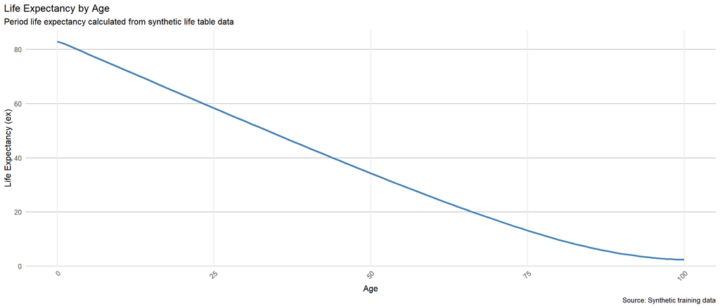

```r
# Create a chart showing life expectancy (ex) by age
# This visualisation helps illustrate how expected remaining years decline with age

ggplot(synthetic_life_table, aes(x = Age, y = ex)) +
  geom_line(color = "steelblue", size = 1.2) +
  scale_y_continuous(limits = c(0, NA), expand = expansion(mult = c(0, 0.05))) +
  labs(
    title = "Life Expectancy by Age",
    subtitle = "Period life expectancy calculated from synthetic life table data",
    x = "Age",
    y = "Life Expectancy (ex)",
    caption = "Source: Synthetic training data"
  ) +
  theme_minimal(base_size = 12) +
  theme(
    plot.title.position = "plot",
    axis.text.x = element_text(angle = 45, hjust = 1),
    panel.grid.major.y = element_line(color = "grey80"),
    panel.grid.minor = element_blank()
  )
```